# IODS course project

# Dimensionality reduction techniques

```r
library(FactoMineR)
library(ggplot2)
library(dplyr)
library(tidyr)
```

```r
human3<-read.csv("human3.csv",row.names=1)
str(human3)
```

```
## 'data.frame':    155 obs. of  8 variables:
##  $ EduRatio            : num  1.007 0.997 0.983 0.989 0.969 ...
##  $ LabRatio            : num  0.891 0.819 0.825 0.884 0.829 ...
##  $ Expected.Edu        : num  17.5 20.2 15.8 18.7 17.9 16.5 18.6 16.5 15.9 19.2 ...
##  $ Life.Expectancy     : num  81.6 82.4 83 80.2 81.6 80.9 80.9 79.1 82 81.8 ...
##  $ GNI                 : int  64992 42261 56431 44025 45435 43919 39568 52947 42155 32689 ...
##  $ Mat.Mor.Ratio       : int  4 6 6 5 6 7 9 28 11 8 ...
##  $ Birth.Rate          : num  7.8 12.1 1.9 5.1 6.2 3.8 8.2 31 14.5 25.3 ...
##  $ Parliment.Percentage: num  39.6 30.5 28.5 38 36.9 36.9 19.9 19.4 28.2 31.4 ...
```

```r
summary(human3)
```

```
##     EduRatio         LabRatio       Expected.Edu   Life.Expectancy
##  Min.   :0.1717   Min.   :0.1857   Min.   : 5.40   Min.   :49.00
##  1st Qu.:0.7264   1st Qu.:0.5984   1st Qu.:11.25   1st Qu.:66.30
##  Median :0.9375   Median :0.7535   Median :13.50   Median :74.20
##  Mean   :0.8529   Mean   :0.7074   Mean   :13.18   Mean   :71.65
##  3rd Qu.:0.9968   3rd Qu.:0.8535   3rd Qu.:15.20   3rd Qu.:77.25
##  Max.   :1.4967   Max.   :1.0380   Max.   :20.20   Max.   :83.50
##       GNI         Mat.Mor.Ratio      Birth.Rate     Parliment.Percentage
##  Min.   :   581   Min.   :   1.0   Min.   :  0.60   Min.   : 0.00
##  1st Qu.:  4198   1st Qu.:  11.5   1st Qu.: 12.65   1st Qu.:12.40
##  Median : 12040   Median :  49.0   Median : 33.60   Median :19.30
##  Mean   : 17628   Mean   : 149.1   Mean   : 47.16   Mean   :20.91
##  3rd Qu.: 24512   3rd Qu.: 190.0   3rd Qu.: 71.95   3rd Qu.:27.95
##  Max.   :123124   Max.   :1100.0   Max.   :204.80   Max.   :57.50
```

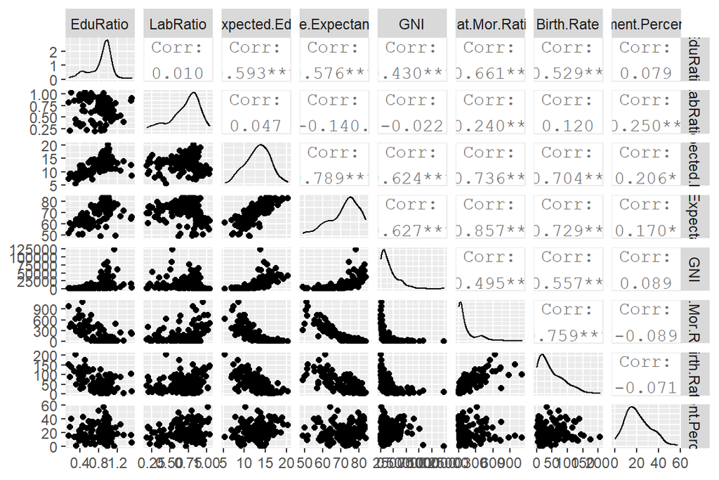

```r
GGally::ggpairs(human3)
```

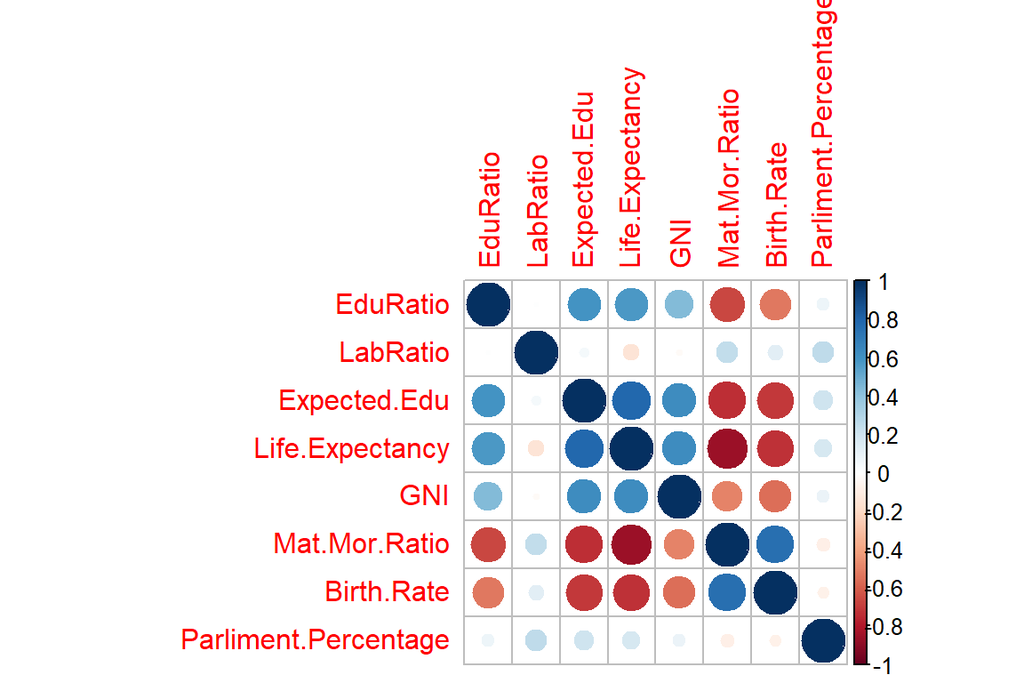

```r
cor(human3)%>%corrplot::corrplot()
```

## PCA without standardising

```r
pca_human<-prcomp(human3)
s<-summary(pca_human)
s
```

```
## Importance of components:
##                              PC1      PC2   PC3   PC4   PC5   PC6    PC7    PC8
## Standard deviation     1.854e+04 185.5219 25.19 11.45 3.766 1.566 0.1912 0.1591
## Proportion of Variance 9.999e-01   0.0001  0.00  0.00 0.000 0.000 0.0000 0.0000
## Cumulative Proportion  9.999e-01   1.0000  1.00  1.00 1.000 1.000 1.0000 1.0000
```

```r
pca_pr <- round(100*s$importance[2, ], digits = 1)
pca_pr
```

```
## PC1 PC2 PC3 PC4 PC5 PC6 PC7 PC8
## 100   0   0   0   0   0   0   0
```

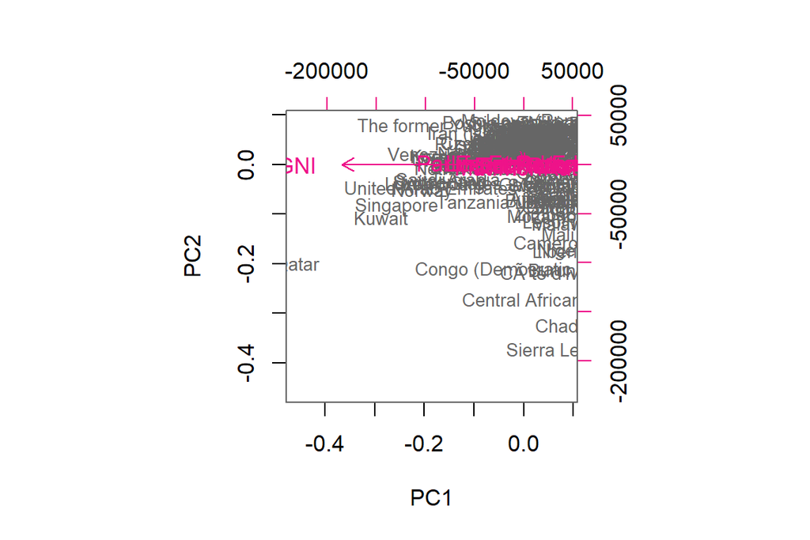

```r
biplot(pca_human, choices = 1:2,cex=c(0.8,1),col=c("grey40", "deeppink2"))
```

## PCA with standardising

```r
pca_human_std<-scale(human3)%>%prcomp()
s_std<-summary(pca_human_std)
s_std
```

```
## Importance of components:
##                           PC1    PC2     PC3     PC4     PC5     PC6     PC7
## Standard deviation     2.0708 1.1397 0.87505 0.77886 0.66196 0.53631 0.45900
## Proportion of Variance 0.5361 0.1624 0.09571 0.07583 0.05477 0.03595 0.02634
## Cumulative Proportion  0.5361 0.6984 0.79413 0.86996 0.92473 0.96069 0.98702
##                            PC8
## Standard deviation     0.32224
## Proportion of Variance 0.01298
## Cumulative Proportion  1.00000
```

```r
pca_pr_std <- round(100*s_std$importance[2, ], digits = 1)
pca_pr_std
```

```
##  PC1  PC2  PC3  PC4  PC5  PC6  PC7  PC8
## 53.6 16.2  9.6  7.6  5.5  3.6  2.6  1.3
```

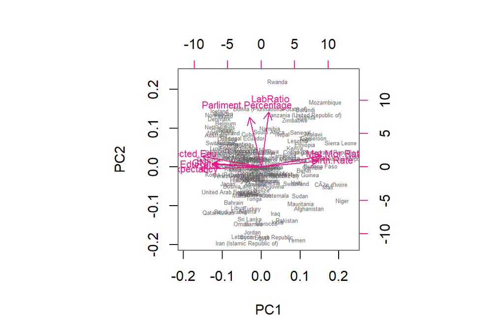

```r
biplot(pca_human_std, choices = 1:2,cex=c(0.4,0.7),col=c("grey40", "deeppink2"))
```

The plot describes the PC components when the data is reduced using the PCA method.PCA essentially transforms the dataset by projecting them onto a set of orthogonal axes. It finds the best linear combination of the original variables so that the variance or spread along the new variable is maximum. The standard deviation of Principal components represent the eigenvalues. For the sake of learning, we will only be looking at PC1 and PC2 since they hold the highest percentage.

The variables are as follows: - Expected.Edu is the espected education in years - GNI refers to Gross National Income per capita - GNI.HDI.RANK refers to the substraction of HDI rank from GNI rank (i.e GNI minus HDI) - Mat.Mor Ratio refers to the number of deaths per 100 000 live births. - Birth.Rate refers to the adolescent births per 1000 women ages 15 - 19. - Parliment percentage refers to the percentage of parliment seats taken up by females - F2Edu & M2Edu refers to secondardy education of both female and male respectively. - FLab & MLab refers the labour force of both female and male respectively. - EduRatio and LabRatio refers to the ratio of female over male for both education and labour respectively.

In the non standardised biplot, the standard dev of PC1 is way higher as compared to the other components.As such, the percentage attributed to PC1 is way higher than the rest. This means that only the first maximum amount of variance if captured but any subsequent is not. This would misrepresent the data, as the angles between each variance arrows and the angle between variable and the axis are important in determining their correlation. As such, standardisation helps to scale each components such that they are independent of each other’s magnitude.

From the standardised biplot, we can now see that the std dev is much closer to each other. As such, we are able to see that the proportion of each PC is more significant than before. From the biplot, we can observe the correlation between each variable (arrow) and against the axis.A few observations can be made: 1)Mat Mor Rat and Birth Rate have very high correlation, which is obvious since the numberr of deaths is based on 100 000birth, which is affected by the birth rate 2) Expected education, GNI, Life expectancy and edu ratio are highly correlated. This is also obvious because gross national income do affect the quality of life and affordable education. 3) Lab ratio and parilment percentage are correlated but not as high as the above 2 points. Since parliment is also a form of labour/job, then the ratio can be expected to be similar. 4) Other than lab ratio and parliment percentage, the 6 other variables are highly correlated to PC1. This means that these few variables are accounted for the maximum spread of the data i.e. mat.mor.ratio and birth rate in a positive manner, the other 4 in a negative manner. 5) The last two variable contributes positively to PC2.

Note: I read up on PCA and found that often, screen plot is done to choose the important PC components. When the sum of PC percentage exceeds 95%, the remaninding PC values can be ignored.